# Structural Based Inundation Notebooks

Objective: Identify a location on a levee to perform a breach simulation using HEC-RAS & calculate inflow hydrograph.

```python
import os, platform
from importlib import reload

import utils; reload(utils)
from utils import *
import maputils; reload(maputils)
from maputils import *
import rasutils; reload(rasutils)
from rasutils import *
import plotly_utils; reload(plotly_utils)
from plotly_utils import *

import warnings
warnings.filterwarnings("ignore")
%matplotlib inline
```

## 1. Assign directories & read in data

In order to perform this analysis, geospatial layers must be imported into a map viewer. Layers required are

- The river centerline of the major flooding source
- HEC-RAS XS which will be used to identify the appropriate elevation for breach height.
- Levee near the XS which will be breached.

```python
# Get Platform
if platform.system() =='Windows':
    data_dir = r'P:\02\NY\Broome_Co_36007C\LAMP\TECHNICAL\StructuralBasedInundation\WORKING\ref_models\Susquehanna2D\shapes'
    flow_dir = r'P:\02\NY\Broome_Co_36007C\LAMP\TECHNICAL\StructuralBasedInundation\WORKING\Hydrology\SBI-Broome\data'
    breach_flow_dir = r'P:\02\NY\Broome_Co_36007C\LAMP\TECHNICAL\StructuralBasedInundation\WORKING\Hydrology\SBI-Broome\weir_flow'
    ras_xs = os.path.join(data_dir, 'xs.geojson')
    levees = os.path.join(data_dir,'levees.geojson')
    river = os.path.join(data_dir,'river.geojson')
    rasdata = r'P:\02\NY\Broome_Co_36007C\LAMP\TECHNICAL\StructuralBasedInundation\WORKING\ref_models\Susquehanna2D\LowerSusquehanna_FW.p02.hdf'

else:

    data_dir = '/Users/slawler/Dewberry/WORKING/Hydrology/SBI-Broome'
    model_dir = '/Users/slawler/Dewberry/WORKING/ref_models/Susquehanna2D/shapes'
    flow_dir = os.path.join(data_dir,'data')
    breach_flow_dir = os.path.join(data_dir, 'weir_flow')
    ras_xs = os.path.join(model_dir, 'xs.geojson')
    levees = os.path.join(model_dir,'levees.geojson')
    river = os.path.join(model_dir,'river.geojson')
    rasdata = '/Users/slawler/Dewberry/models/Susquehanna/LowerSusquehanna_FW.p02.hdf'
```

### 2. Create an interactive map to view the data

1. Zoom to the levee that will be breached. Click on one of the levee points and note the levee segment ID.
2. Find the nearest XS. Click on the XS end point and note the XS station ID.

```python
m = init_area_map(levees, ras_xs, river, width=1100, height=600, zoom = 14)
m
```

[interactive chart not shown]

### 3. Enter data from map for US Breach

1. Levee ID from above
2. XS ID from above
3. Descriptive code for levee breach location (e.g. US for upstream)
4. Print list of available profiles fromt the RAS plan

```python
LeveeID = '21'
Hydrograph = 'Levees_21.csv'

xs = '174908'
breach_point = 'US'

xs_ids = GetRasXS_ids(rasdata)
for i, x in enumerate(xs_ids):
    if xs_ids[x] == xs: print('XS #{}, Station {}\n'.format(i ,xs_ids[x]));break

profiles = GetRasXS_profiles(rasdata)
printbold('XS Data/Flows Read in succesfully')
#for i, p in enumerate(profiles): print(i,'\t', profiles[p])
```

```
XS #85, Station 174908
```

**XS Data/Flows Read in succesfully**

### 4. Read RAS geometry data & plot US XS with selected profile

1. Enter the idx corresponding to the LAMP flow (1%)
2. In the plot that appears, zoom to the levee & find a point on the XS to set as breach height
3. Note the station at the desired location

```python
profile_idx = 18 # profile index from above (wse)

# Get wse at XS for selected profile
wse = GetRasXS_wse(rasdata, profiles, profile_idx , xs_ids, xs )

# Get XS geometry
xs_line = GetRasXS_lines(rasdata, xs_ids,  xs)

# Get XS Bank Stations
bank_stations = GetRasXS_bank_Stations(rasdata, xs_ids)
bs, be = bank_station_at_xs(bank_stations, xs, xs_line)

# Plot the XS, identify breach location
plotly_ras_xs(xs, xs_line, wse, bs, be)
```

[interactive chart not shown]

### 5. Replot w/Breach Location & Rating Curve

1. Enter in breach station
   - Read in data from the 1D RAS model.
   - Create a rating curve to translate flow to stage near the breach location.

```python
ts = 2337.78 # input the XS station
te = xs_line[xs_line[0] == ts][1].values[0] # find the toe elevation (breach invert)
plotly_ras_xs(xs, xs_line, wse, bs, be, ts, te, breach_elev=True, notebook=True)

station = int(xs)
breach_elev = te

rastable = GetRasData(rasdata, station)                    # Read in ras data from station of interest
RC_Plot(rastable, xlabel = 'Flow', ylabel = 'Stage', title = 'Rating Curve for XS {}'.format(station), notebook=True)
rc_fit   = make_rc_fitline(rastable)                       # Using data from rastable, create a rc-function
```

[interactive chart not shown]

**RAS Data for XS 174908**

[interactive chart not shown]

### 6. Bring in the Base Hydrograph

- For each change location in the model, there should be a 1% flow hydrograph. Read this in as the 'Base Hydrograph'

**Stretched Hydrograph: 1% Chance**

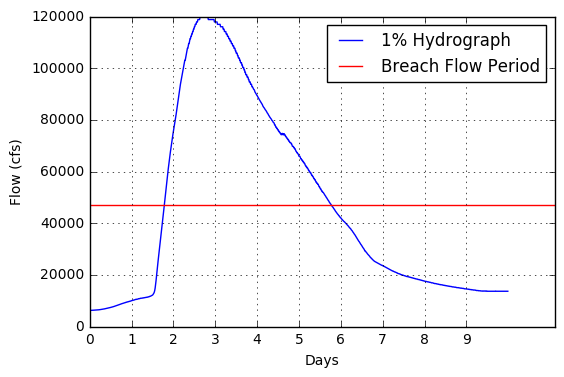

```python
base_hydrograph = pd.read_csv(os.path.join(flow_dir, Hydrograph), index_col='Minutes')
base_hydrograph['stage'] = rc_fit(base_hydrograph['Stretched Hydrograph'])
bft =  BreachFlowTrigger(base_hydrograph, breach_elev)
showplot = plot_hydrograph_days(base_hydrograph, breach_elev)
#Flow_BFT_Plot(base_hydrograph, 'Stretched Hydrograph', bft,  xlabel = None, ylabel = None, title = None, notebook=True)
printbold('Stretched Hydrograph: 1% Chance')
```

### 7. Compute Stage, Head & Weir Flow at XS using Base Hydrograph

Using the base hydrograph & the rating curve:

1. Calculate stage time series for 1% flow above the selected breach elevation
2. Convert the stage to head for weir flow calculation
3. Calculate weir flow & plot

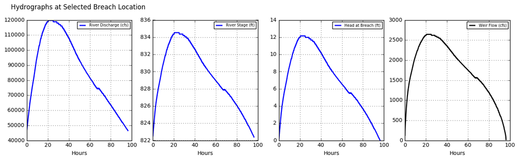

```python
base_hydrograph['stage'] = rc_fit(base_hydrograph['Stretched Hydrograph'])
df_weir = ComputeWeirFlow_num_ords(base_hydrograph, breach_elev, breach_length = 250, plot = True)
```

### OPTIONAL: Sensitivity Analysis

- Plot sensitivity to breach height & weir coefficient at the breach location.

```python
#BreachLength_Sensitivity(base_hydrograph, breach_elev)
#WeirCoeff_Sensitivity(base_hydrograph, breach_elev, figsize=(12,6))
```

### 8. Save results to file

*If desired, adjust assumptions based on sensitivity analysis.

```python
ras_unsteady_file = os.path.join(breach_flow_dir, 'Levee_{}_{}_{}.csv'.format(LeveeID, xs,breach_point ))
df_weir['weir_flow'].to_csv(ras_unsteady_file)
print('Unsteady flow data save to: {}'.format(ras_unsteady_file))
```

```
Unsteady flow data save to: P:\02\NY\Broome_Co_36007C\LAMP\TECHNICAL\StructuralBasedInundation\WORKING\Hydrology\SBI-Broome\weir_flow\Levee_21_174908_US.csv
```

### 9. Refresh map & enter data for DS breach

1. Levee ID from above
2. XS ID from above
3. Descriptive code for levee breach location (e.g. US for upstream)
4. Print list of available profiles fromt the RAS plan

```python
m
```

[interactive chart not shown]

```python
xs = '173736'
breach_point = 'DS'

xs_ids = GetRasXS_ids(rasdata)
for i, x in enumerate(xs_ids):
    if xs_ids[x] == xs: print('XS #{}, Station {}\n'.format(i ,xs_ids[x]));break

profiles = GetRasXS_profiles(rasdata)
printbold('XS Data/Flows Read in succesfully')
#print('idx', '\tplan')
#for i, p in enumerate(profiles): print(i,'\t', profiles[p])
```

```
XS #87, Station 173736
```

**XS Data/Flows Read in succesfully**

### 10. Read RAS geometry data & plot XS with selected profile

1. Enter the idx corresponding to the LAMP flow (1%)
2. In the plot that appears, zoom to the levee & find a point on the XS to set as breach height
3. Note the station at the desired location

```python
profile_idx = 18 # profile index from above (wse)

# Get wse at XS for selected profile
wse = GetRasXS_wse(rasdata, profiles, profile_idx , xs_ids, xs )

# Get XS geometry
xs_line = GetRasXS_lines(rasdata, xs_ids,  xs)

# Get XS Bank Stations
bank_stations = GetRasXS_bank_Stations(rasdata, xs_ids)
bs, be = bank_station_at_xs(bank_stations, xs, xs_line)

# Plot the XS, identify breach location
plotly_ras_xs(xs, xs_line, wse, bs, be)
```

[interactive chart not shown]

### 11. Replot wioth Rating Curve

1. Enter in breach station

```python
ts = 2537.385 # input the XS station
te = xs_line[xs_line[0] == ts][1].values[0] # find the toe elevation (breach invert)
plotly_ras_xs(xs, xs_line, wse, bs, be, ts, te, breach_elev=True, notebook=True)

station = int(xs)
breach_elev = te

rastable = GetRasData(rasdata, station)                    # Read in ras data from station of interest
RC_Plot(rastable, xlabel = 'Flow', ylabel = 'Stage', title = 'Rating Curve for XS {}'.format(station), notebook=True)
rc_fit   = make_rc_fitline(rastable)                       # Using data from rastable, create a rc-function
```

[interactive chart not shown]

**RAS Data for XS 173736**

[interactive chart not shown]

### 12. Bring in the Base Hydrograph

- For each change location in the model, there should be a 1% flow hydrograph. Read this in as the 'Base Hydrograph'

**Stretched Hydrograph: 1% Chance**

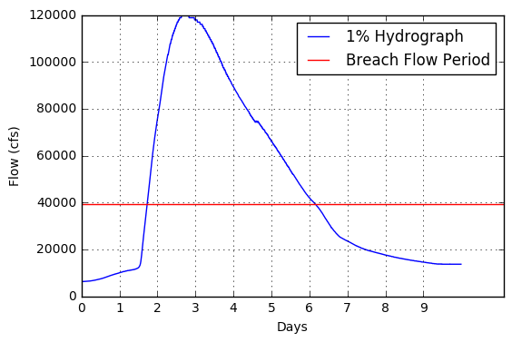

```python
Hydrograph = 'Levees_21.csv'
base_hydrograph = pd.read_csv(os.path.join(flow_dir, Hydrograph), index_col='Minutes')
base_hydrograph['stage'] = rc_fit(base_hydrograph['Stretched Hydrograph'])
bft =  BreachFlowTrigger(base_hydrograph, breach_elev)
showplot = plot_hydrograph_days(base_hydrograph, breach_elev)
#Flow_BFT_Plot(base_hydrograph, 'Stretched Hydrograph', bft,  xlabel = None, ylabel = None, title = None, notebook=True)
printbold('Stretched Hydrograph: 1% Chance')
```

### 13. Compute Stage, Head & Weir Flow at DS XS using Base Hydrograph

Using the base hydrograph & the rating curve:

1. Calculate stage time series for 1% flow above the selected breach elevation
2. Convert the stage to head for weir flow calculation
3. Calculate weir flow & plot

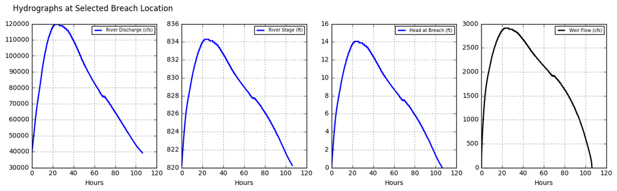

```python
base_hydrograph['stage'] = rc_fit(base_hydrograph['Stretched Hydrograph'])
df_weir = ComputeWeirFlow_num_ords(base_hydrograph, breach_elev, breach_length = 250, plot = True)
```

### OPTIONAL: Sensitivity Analysis

- Plot sensitivity to breach height & weir coefficient at the breach location.

```python
#BreachLength_Sensitivity(base_hydrograph, breach_elev)
#WeirCoeff_Sensitivity(base_hydrograph, breach_elev, figsize=(12,6))
```

### 14. Save results to file

*If desired, adjust assumptions based on sensitivity analysis.

```python
ras_unsteady_file = os.path.join(breach_flow_dir, 'Levee_{}_{}_{}.csv'.format(LeveeID, xs,breach_point ))
df_weir['weir_flow'].to_csv(ras_unsteady_file)
print('Unsteady flow data save to: {}'.format(ras_unsteady_file))
```

```
Unsteady flow data save to: P:\02\NY\Broome_Co_36007C\LAMP\TECHNICAL\StructuralBasedInundation\WORKING\Hydrology\SBI-Broome\weir_flow\Levee_21_173736_DS.csv
```